# Informe N65 Semanal de Covid-19

[figure not shown]

# Pacientes en UCI por Covid-19 superan el máximo de la tercera ola.

En este informe presentamos el Analisis Semanal Nº65 de Covid-19 elaborado por el Grupo Epidemiológico Matemático para la Vigilancia de Epidemias y Pandemia (GEMVEP) de la Universidad de Santiago. Los datos usados en este informe consideran los casos de Covid-19 informados entre el 04 de Febrero y el 10 de Febrero .Los datos provienen de las siguientes fuentes de información:

- [Reporte Covid-19 del dia Jueves 10 de Febrero del Ministerio de Salud](https://s3.amazonaws.com/gobcl-prod/public_files/Campa%C3%B1as/Corona-Virus/Reportes/10.02.2022_Reporte_Covid19.pdf)
- [Informe Epidemiológico con datos hasta el Lunes 7 de Febrero del Ministerio de Salud](https://www.minsal.cl/wp-content/uploads/2022/02/Informe-Epidemiolo%CC%81gico-172.pdf)
- [Informe de Testeo, Trazabilidad y Aislamiento del del Ministerio de Salud](https://www.minsal.cl/wp-content/uploads/2022/01/Informe-TTA-09-al-15-de-enero.pdf)
- [Datos de Defunciones desde el Departamento de Estadísticas e Información de Salud](https://deis.minsal.cl/)

## Balance Nacional Semanal

En la ultima semana se han confirmado 234117 casos de Covid-19 en Chile. Una tasa de incidencia de 171.88 casos promedio por día cada 100.000 habitantes.Esta es la mayor incidencia en Chile desde el inicio de la pandemía. Además, los casos aumentaron en un 18.36% respecto de la semana anterior,mientras que la variación de casos a 14 días es de un 104.64%.Nuestra estimación del R Efectivo a nivel nacional es de 1.24. La incidencia actual esta 17.2 veces sobre un nivel crítico de contagios. Finalmente, de acuerdo al reporte del Departamento de Estadísticas e Información de Salud (DEIS) del Ministerio de Salud, 51.012 personas han fallecido en Chile a causa del Covid-19 (Información hasta 02 de Febrero). Una tasa de 262.16 personas c/100.000hab. 39.930 con confirmación de PCR (tasa de 205.21 c/100.000hab) y 11.082 sin confirmación. Hasta la fecha 818 personas han fallecido por Covid-19 en 2022.

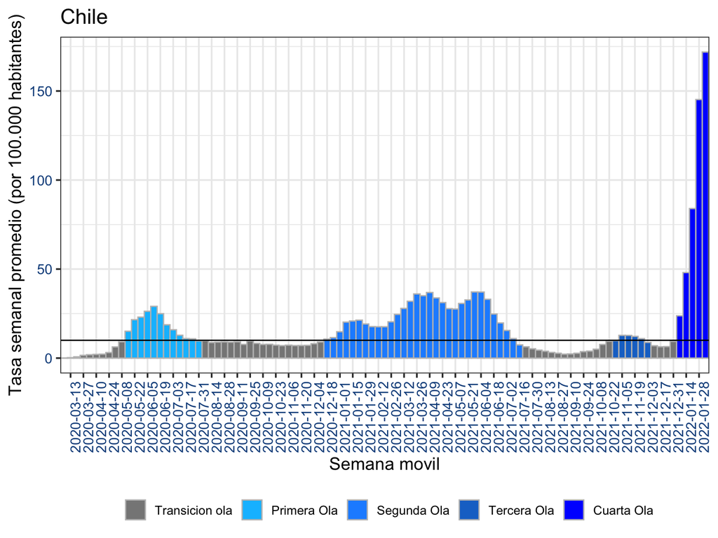

Promedio Semanal de Incidencia de contagios de Covid-19 en Chile cada 100.000 habitantes

En la comparación con los países de Sudamerica, Chile se encuentra en el lugar 2 entre los países con la mayor tasa de incidencia. En America, Chile está en el lugar 3 entre 47 países.A nivel mundial Chile está en el lugar 34 entre los 228 países analizados.

Si analizamos las cifras de vacunación, observamos en Chile que el 88.6 % de la población total tiene su esquema de vacunación completo. En la comparación con los países de Sudamerica, Chile se encuentra en el lugar 1 entre los países con la mayor cobertura de vacunación. En America, Chile está en el lugar 1 entre 47 países.A nivel mundial Chile está en el lugar 4 entre los 229 países analizados.

## Análisis Regional

Las regiones con las mayores tasas de incidencia promedio en la ultima semana son:

Aysen 316.21 casos cada 100.000 habitantes  
Los Rios 269.25  
Atacama 257.83  
Nuble 220.42  
Araucania 214.92

Las regiones con las menores tasas de incidencia promedio en la ultima semana son:

Metropolitana 150.75 casos cada 100.000 habitantes  
Ohiggins 144.25  
Tarapaca 95.13

Actualmente, 16 de 16 regiones del país tienen un nivel crítico de contagios.

Además, 12 de 16 regiones del país han aumentado casos de Covid-19 en los últimos 7 días. Las regiones con los mayores aumentos de casos de Covid-19 en la ultima semana son:

Nuble + 54.7 %  
Maule + 53.04 %  
Los Rios + 52.92 %  
Atacama + 49.75 %  
Aysen + 44.03 %  
Mientras que las regiones con las mayores disminuciones de casos de Covid-19 en la ultima semana son:

Magallanes -17.19 %  
Antofagasta -20.47 %  
Tarapaca -49.87 %

En la siguiente figura mostramos nuestro balance de indicadores de circulación del Covid-19 por región del país en la ultima semana.

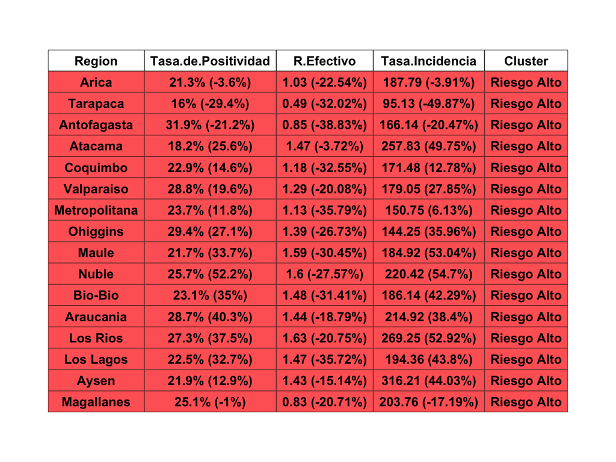

Balance Semanal: Tasa de Incidencia es número de casos nuevos en la última semana cada 100.000 habitantes, Tasa de positividad es numero de casos nuevos confirmados con PCR dividido numero de examenes PCR por semana

## Hospitalizaciones

El número de pacientes con Covid-19 en UCI informados el 10 de Febrero fue 720 ( 196 mas que semana previa) . No se informaban tantos pacientes Covid-19 en UCI desde la segunda ola (724 el 28 de Agosto de 2021). Durante la tercera ola el máximo valor informado fue 706 (2 de Diciembre).Además, este día se informaron 575 pacientes Covid-19 en ventilación mecánica invasiva (VMI) ( 175 mas que semana previa) .  
Las regiones con mayor porcentaje de ocupación UCI al día son:

Atacama 100 %  
Valparaiso 97.13 %  
Antofagasta 96.2 %  
Coquimbo 96.15 %  
Araucania 93.83 %  
Este dia, 12 de las 16 regiones del país tuvieron una ocupación de camas UCI superior al 80%.Las regiones que tuvieron menor ocupación UCI son:

Arica 77.78 %  
Nuble 77.78 %  
Aysen 60 %

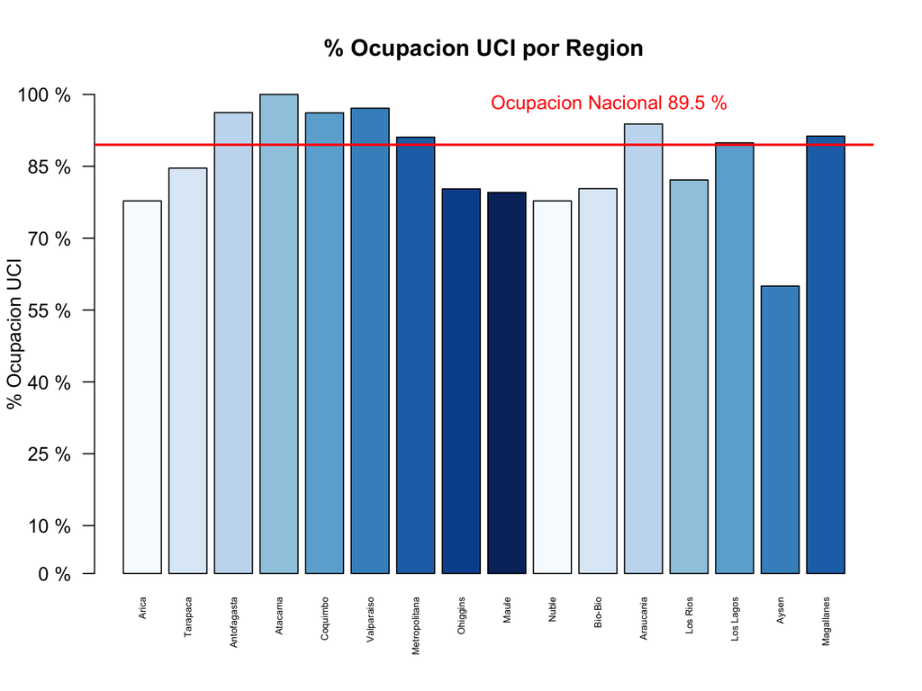

Porcentaje de Ocupación UCI por Region

Las regiones con menor cantidad de camas UCI disponibles son:

Atacama 0 camas UCI disponibles  
Coquimbo 2  
Magallanes 2  
Antofagasta 3  
Arica 4  
Las regiones con mayor proporción de camas UCI usadas sobre el basal de camas UCI disponibles en 2019 son:

Tarapaca 275 %  
Nuble 218.75 %  
Los Lagos 181.63 %  
Los Rios 176.92 %  
Atacama 172.73 %  
Este dia, 14 de las 16 regiones del país tienen una ocupación sobre el 100% de camas bases del año 2019.

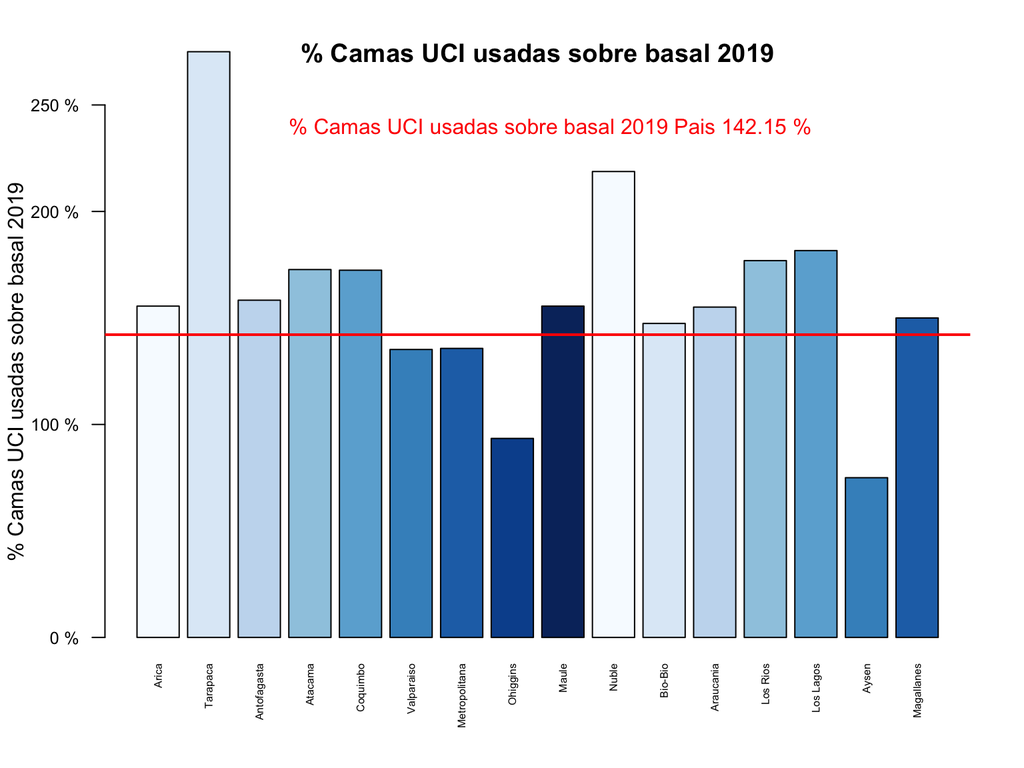

Porcentaje de Ocupación UCI sobre basal de camas disponibles en 2019 por Region

## Análisis por Edad

En el análisis por edad notamos que el grupo etario con mayor cantidad de casos nuevos de Covid-19 en la última semana son las personas entre 15 y 29 años con 59977 casos en los últimos 7 días. Esto corresponde a un 25.16% del total de la población contagiada. Además, el grupo etario con el mayor aumento de casos en la última semana es el tramo mayores de 70 años con un aumento del 48.54% respecto a la semana previa.

Además, respecto a las hospitalizaciones, el grupo etario con mayor cantidad de pacientes Covid-19 en UCI son las personas mayores de 70 años que cuenta con 281 pacientes Covid-19 en UCI. Esto corresponde a un 40.84% del total. Además, el grupo etario con mayor aumento de pacientes Covid-19 en UCI es el grupo de personas mayores de 70 años con un aumento del 69.28% respecto a la semana previa

## Situación Comunal

En el analisis comunal notamos que 340 de 346 comunas del país tienen un nivel crítico de contagios.

Las comunas de más de 25.000 habitantes con las mayores tasas de incidencia promedio en la ultima semana son:

Quellon 325.11 casos cada 100.000 habitantes  
Coyhaique 307.61  
Aysen 295.4  
Chillan 289.71  
Arica 274.75  
Pucon 268.14  
Valdivia 255.61  
Santiago 236.62  
Copiapo 235.04  
Casablanca 230.67

Las comunas de más de 25.000 habitantes con mayor aumento de casos en la ultima semana son:

Lebu + 247.44 %  
Carahue + 169.66 %  
Calbuco + 134.62 %  
Ancud + 126.78 %  
Constitucion + 117.5 %  
Hualqui + 116.15 %  
San Clemente + 113.89 %  
Aysen + 111.02 %  
Mostazal + 110.71 %  
Llaillay + 106.01 %  
Las comunas de más de 25.000 habitantes con mayor tasa de positividad del examen PCR en la ultima semana son:

Calama 34.3 %  
Alto Hospicio 33.3 %  
La Ligua 32.8 %  
San Ramon 32.7 %  
Iquique 32 %  
Talagante 32 %  
Salamanca 31.7 %  
Antofagasta 30.7 %  
Cartagena 30.1 %  
Punta Arenas 30.1 %

## Trazabilidad

Según el último informe de Testeo, Trazabilidad y Aislamiento de esta semana, en Chile se encuentran solo 9.189 contactos antes de las primeras 48 horas. Esto implica una razón de contactos por caso de solo 0.05.

# Indicadores usados:

- R Efectivo: La tasa de reproducción efectiva fue calculada a nivel regional usando el método de Cori implementado en el paquete EpiEstim de R.
- Tasa de Incidencia: Casos Diarios cada 100.000 habitantes promedio en los últimos 7 días.
- Tasa de Positividad: Casos Confirmados por Test PCR dividido el número de exámenes PCR en la última semana.
- Variación de Casos: Corresponde a la variación relativa de casos en la semana vigente respecto a la semana previa.

Para la definición de regiones en Riesgo Alto, Medio y Bajo se usa un procedimiento de cluster que se basa en incidencia, positividad y R efectivo en ultimos 7 días y su variación respecto a la semana anterior.